# Statistical Inference Part 1 - Simulation

Sunday, July 26, 2015

## Overview

In this course project we will investigate the exponential distribution in R and compare it with the Central Limit Theorem. The exponential distribution can be simulated in R with rexp(n, lambda) where lambda is the rate parameter. The mean of exponential distribution is 1/lambda (1/$\lambda$) and the standard deviation is also 1/lambda (1/$\lambda$). We will set lambda = 0.2 for all of the simulations. We will investigate the distribution of averages of 40 exponentials.

## Simulations

Let’s do a thousand simulated averages of 40 exponentials.

```r
set.seed(3) # This is to ensure the same random sample is selected each time
lambda <- 0.2 #set our lamda
number_of_simulations <- 1000
sample_size <- 40
simulation <- matrix(rexp(number_of_simulations*sample_size, rate=lambda),
                     number_of_simulations, sample_size)
row_means <- rowMeans(simulation)
```

## The distribution of sample means is as follows.

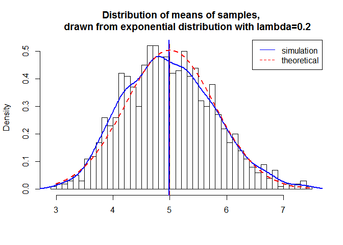

## Sample Mean versus Theoretical Mean

The expected mean $\mu$ of a exponential distribution of rate $\lambda$ is

$\mu= \frac{1}{\lambda}$

```r
mu <- 1/lambda
mu
```

```
## [1] 5
```

Let $\bar X$ be the average sample mean of 1000 simulations of 40 randomly sampled exponential distributions.

```r
meanOfMeans <- mean(row_means)
meanOfMeans
```

```
## [1] 4.98662
```

As you can see the expected mean and the avarage sample mean are very close. This is also shown in the graph above with the expected mean in Red vertical line and the sample mean in the Blue verical line.

## Sample Variance versus Theoretical Variance

$\sigma = \frac{1/\lambda}{\sqrt{n}}$

```r
sd <- 1/lambda/sqrt(sample_size)
sd
```

```
## [1] 0.7905694
```

The variance $Var$ of standard deviation $\sigma$ is

$Var = \sigma^2$

```r
Var <- sd^2
Var
```

```
## [1] 0.625
```

Let $Var_x$ be the variance of the average sample mean of 1000 simulations of 40 randomly sampled exponential distribution, and $\sigma_x$ the corresponding standard deviation.

```r
sd_x <- sd(row_means)
sd_x
```

```
## [1] 0.7910484
```

```r
Var_x <- var(row_means)
Var_x
```

```
## [1] 0.6257575
```

As you can see the standard deviations are very close Since variance is the square of the standard deviations, minor differnces will we enhanced, but are still pretty close.